# Medical Cost Differences Between Patient Clusters in the U.S.

Xiran Wang

Department of Statistics, University of South Carolina  
xiranwangwork@gmail.com

11-28-2018

## I. Advanced Inference for Linear Regression

This work uses MEPS dataset to address the question of whether men and women use roughly the same quantity of medical services at each age. That is, determine whether the age-dependence of average transformed medical expenditures (log10($+100)) is roughly the same for men and for women.

## II. Dataset Availability

The dataset is provided by Medical Expenditure Panel Survey (MEPS).And the code book is available at https://meps.ahrq.gov/mepsweb/data_stats/download_data_files_codebook.jsp?PUFId=H129&sortBy=Start.

## III. Data Visualization

**3.1 Total medical expenditure versus age**

The age is a key continuous variable to predict medical expendicture. Here, two plots show the smoothed trend of total raw medical expenditure and logarithmic expenditure(with based 10) and the “jittered” points are medical expenditures located by age.

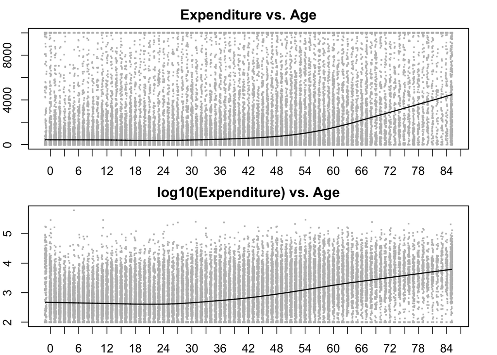

```r
par(mfrow=c(2,1))
par(mar=c(2, 2, 2, 2))
plot(exp1w~jitter(h129.AGE09X,1), data = newdata,
     col='grey', pch=15, cex=0.3, xaxt='n', xlab='Age',
     ylab='Expenditure', main = "Expenditure vs. Age")
axis(1,seq(0,90,by=3))
lines(lowess(newdata$exp1w~newdata$h129.AGE09X,f=2/5), lwd =1.5) # lowess function- smooth method


plot(lexp~jitter(h129.AGE09X,1), data = newdata,
     col='grey', pch=15, cex=0.3 ,xaxt='n', xlab='Age',
     ylab='Log10(expenditure)', main="log10(Expenditure) vs. Age")
axis(1,seq(0,90,by=3))
lines(lowess(newdata$lexp~newdata$h129.AGE09X,f=2/5), lwd = 1.5)
```

**3.2 Total medical expenditure versus gender**

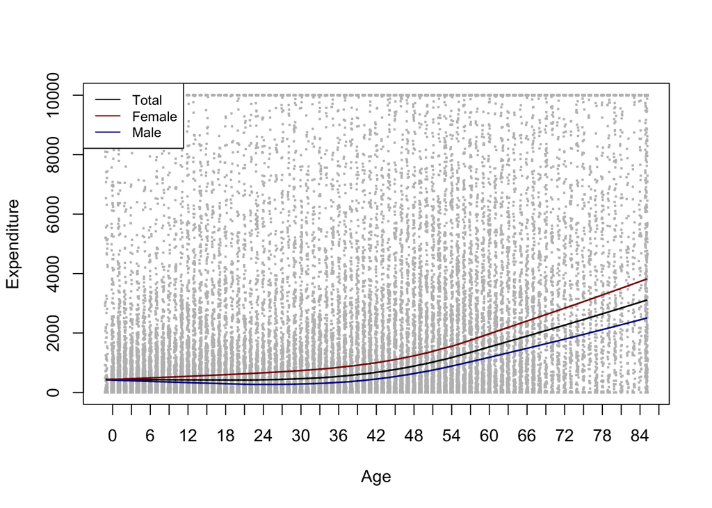

```r
male   <- newdata[which(newdata$h129.SEX==1),]
female <- newdata[which(newdata$h129.SEX==2),]

par(mfrow=c(1,1))
plot(exp1w~jitter(h129.AGE09X,1), data = newdata,
     col='grey', pch=15, cex=0.3, xaxt='n', xlab='Age', ylab='Expenditure')
axis(1, seq(0, 90, by=3))
lines(lowess(newdata$exp1w~newdata$h129.AGE09X, f=2/3), lwd=1.5)
lines(lowess(male$exp1w~male$h129.AGE09X, f=2/3), col='dark blue', lwd=1.5)
lines(lowess(female$exp1w~female$h129.AGE09X, f=2/3),col='dark red', lwd=1.5)
legend('topleft', legend=c("Total", "Female", "Male"),
       col=c( "black","dark red", "dark blue "), lty=c(1,1,1), cex=0.8)
```

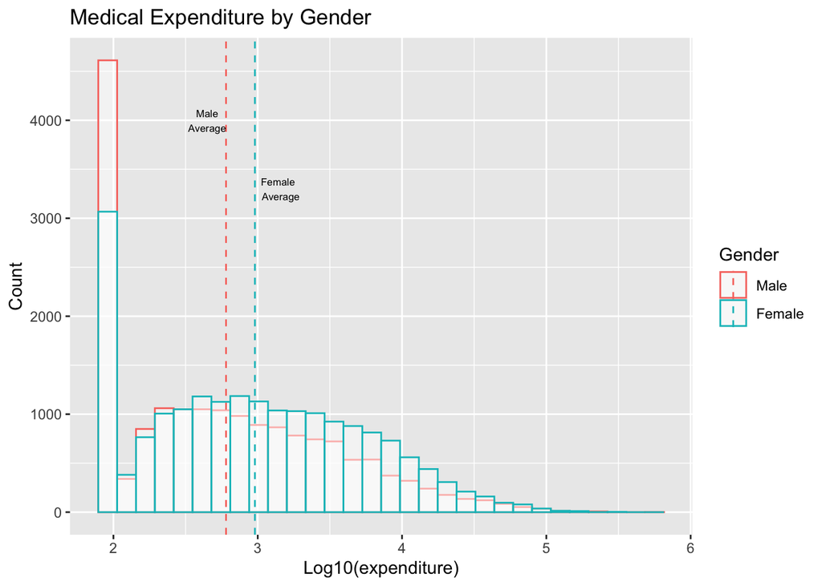

```r
library(ggplot2)
library(plyr)

mu <- ddply(newdata, "h129.SEX", summarise, grp.mean=mean(lexp))
# histogram plot -  colored by gender
ggplot(newdata, aes(x=lexp,fill=factor(h129.SEX), color=factor(h129.SEX))) +
  geom_histogram(fill="white", position="identity",alpha=0.5) +
  labs(title="Medical Expenditure by Gender", x= "Log10(expenditure)", y = "Count") +
  geom_vline(data=mu, aes(xintercept=grp.mean, color=factor(h129.SEX)), linetype="dashed")+
  scale_color_discrete(name = "Gender", labels=c("Male", "Female")) +
  annotate(geom=c("text"), x=2.65, y=4000, label="Male\nAverage", color="black", size=2.2)+
  annotate(geom=c("text"), x=3.15, y=3300, label="Female \n Average", color="black", size=2.2)
```

```r
mu$h129.SEX<-c( "Male","Female" )
colnames(mu)= c("Gender","Group.mean")
kable(mu)%>%
  kable_styling(bootstrap_options = "striped", full_width = F)
```

| Gender | Group.mean |
| --- | --- |
| Male | 2.780482 |
| Female | 2.980566 |

## IV. Data Analysis

```r
library(plotrix)
library(TeachingDemos)
library(plotmo)
library(earth)
```

**4.1 Age effect**

```r
mars <- earth(h129.TOTEXP09 ~ h129.AGE09X, data = newdata)
summary(mars) # identify knot
```

```
## Call: earth(formula=h129.TOTEXP09~h129.AGE09X, data=newdata)
##
##                   coefficients
## (Intercept)         2198.41919
## h(39-h129.AGE09X)    -14.63003
## h(h129.AGE09X-39)    200.17017
##
## Selected 3 of 3 terms, and 1 of 1 predictors
## Termination condition: RSq changed by less than 0.001 at 3 terms
## Importance: h129.AGE09X
## Number of terms at each degree of interaction: 1 2 (additive model)
## GCV 114911638    RSS 4.233919e+12    GRSq 0.05027195    RSq 0.0504781
```

```r
agesp1 <- ifelse(newdata$h129.AGE09X > 39, newdata$h129.AGE09X-39, 0)
fitspline <- lm(h129.TOTEXP09 ~ h129.AGE09X + agesp1,data = newdata)
summary(fitspline)
```

```
##
## Call:
## lm(formula = h129.TOTEXP09 ~ h129.AGE09X + agesp1, data = newdata)
##
## Residuals:
##    Min     1Q Median     3Q    Max
## -11406  -2399  -1686   -712 614930
##
## Coefficients:
##             Estimate Std. Error t value Pr(>|t|)
## (Intercept) 1627.848    127.816   12.74  < 2e-16 ***
## h129.AGE09X   14.630      4.993    2.93  0.00339 **
## agesp1       185.540      9.507   19.52  < 2e-16 ***
## ---
## Signif. codes:  0 '***' 0.001 '**' 0.01 '*' 0.05 '.' 0.1 ' ' 1
##
## Residual standard error: 10720 on 36852 degrees of freedom
## Multiple R-squared:  0.05048,    Adjusted R-squared:  0.05043
## F-statistic: 979.6 on 2 and 36852 DF,  p-value: < 2.2e-16
```

**4.3 Age and gender effect**

```r
#female is 0, and male is 1
fitlinear<-lm(h129.TOTEXP09~h129.AGE09X+factor(gender),data=newdata )
summary(fitlinear)
```

```
##
## Call:
## lm(formula = h129.TOTEXP09 ~ h129.AGE09X + factor(gender), data = newdata)
##
## Residuals:
##    Min     1Q Median     3Q    Max
##  -8804  -3526  -1736    -64 616344
##
## Coefficients:
##                 Estimate Std. Error t value Pr(>|t|)
## (Intercept)       460.32     117.82   3.907 9.36e-05 ***
## h129.AGE09X        98.16       2.51  39.112  < 2e-16 ***
## factor(gender)1  -663.79     112.50  -5.900 3.66e-09 ***
## ---
## Signif. codes:  0 '***' 0.001 '**' 0.01 '*' 0.05 '.' 0.1 ' ' 1
##
## Residual standard error: 10770 on 36852 degrees of freedom
## Multiple R-squared:  0.04157,    Adjusted R-squared:  0.04152
## F-statistic: 799.2 on 2 and 36852 DF,  p-value: < 2.2e-16
```

**4.4 Model diagnostics**

Based on residual plot for the model,the residuals are not normally distributed, and equal variance doesn’t hold for these errors. Q-Q plot and boxplot also show the evidences that the residuals have fewer possiblities to be linearlity, residuals might be skewed. In addition, I need to check both influential points and outliers: a few observations should not dominate the model fit.

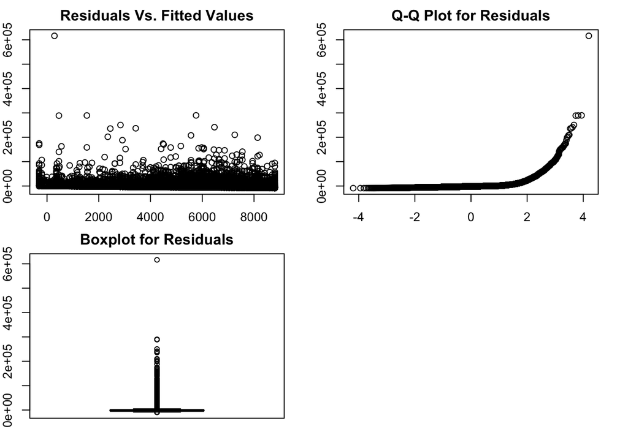

```r
par(mfrow=c(2,2))
par(mar=c(2,2,2,2))
plot(fitlinear$fitted.values,summary(fitlinear)$residuals , main ="Residuals Vs. Fitted Values")
qqnorm(fitlinear$residuals,main= "Q-Q Plot for Residuals")
boxplot(fitlinear$residuals,main= "Boxplot for Residuals")
```

**4.5 Log10 trasformation on dependent variable**

The model estimates in the MLR model(fitlinear) is likely to be substantially influenced by one or a few extreme observations. A better alternative is to model lexp=log10(expenditure + 100). Fit a MLR of log10 expenditure on age (possibly with splines), gender, and interaction between age (possibly with splines), gender, and interaction between age (possibly with splines) and gender.

```r
mars1 <- earth(lexp~h129.AGE09X,data = newdata)
summary(mars1)  # knot for spline
```

```
## Call: earth(formula=lexp~h129.AGE09X, data=newdata)
##
##                   coefficients
## (Intercept)         2.62792397
## h(29-h129.AGE09X)   0.00270968
## h(h129.AGE09X-29)   0.01968099
##
## Selected 3 of 3 terms, and 1 of 1 predictors
## Termination condition: RSq changed by less than 0.001 at 3 terms
## Importance: h129.AGE09X
## Number of terms at each degree of interaction: 1 2 (additive model)
## GCV 0.4496437    RSS 16567.12    GRSq 0.1565088    RSq 0.1566919
```

```r
agesp1 <- ifelse(newdata$h129.AGE09X>29, newdata$h129.AGE09X-29,0)
fitmlr <- lm(lexp~ h129.AGE09X + agesp1 + factor(gender) + h129.AGE09X*factor(gender) + factor(gender)*agesp1, data = newdata)
summary(fitmlr)
```

```
##
## Call:
## lm(formula = lexp ~ h129.AGE09X + agesp1 + factor(gender) + h129.AGE09X *
##     factor(gender) + factor(gender) * agesp1, data = newdata)
##
## Residuals:
##      Min       1Q   Median       3Q      Max
## -1.76900 -0.50946 -0.05394  0.44004  3.08007
##
## Coefficients:
##                               Estimate Std. Error t value Pr(>|t|)
## (Intercept)                  2.6483728  0.0127098 208.372  < 2e-16 ***
## h129.AGE09X                  0.0058246  0.0006150   9.471  < 2e-16 ***
## agesp1                       0.0098246  0.0008750  11.228  < 2e-16 ***
## factor(gender)1              0.1228269  0.0176756   6.949 3.74e-12 ***
## h129.AGE09X:factor(gender)1 -0.0180601  0.0008742 -20.658  < 2e-16 ***
## agesp1:factor(gender)1       0.0265649  0.0012736  20.858  < 2e-16 ***
## ---
## Signif. codes:  0 '***' 0.001 '**' 0.01 '*' 0.05 '.' 0.1 ' ' 1
##
## Residual standard error: 0.6611 on 36849 degrees of freedom
## Multiple R-squared:  0.1802, Adjusted R-squared:  0.1801
## F-statistic:  1620 on 5 and 36849 DF,  p-value: < 2.2e-16
```

Here , I test the null hypothesis that the dependence of mean Log10(expenditure) on age is the same for men and women. Output shows the results of the partial F-test. Since F=352.28 (p-value< 2.2e-16).We reject the null hypothesis ($\beta_2 = \beta_3 = \beta_4 =0$) at the 5% level of significance. It appears that the variables “gender”,“gender*age“,and”gender*I(age>29) contribute the significant information tomean(Lexpend), which also means there are interation between gender and age, as well as between gender and I(age>29), once the variables age and I(age>29) have been taken into consideration. Overall,the dependence of mean(Lexpend) on age is not the same for men and women.

```r
reduced <- lm(lexp~ h129.AGE09X + agesp1, data = newdata)
fitmlr  <- lm(lexp~ h129.AGE09X + agesp1 + factor(gender) + h129.AGE09X*factor(gender) + agesp1*factor(gender)
           , data = newdata)

kable(anova(reduced,fitmlr) ) %>%
  kable_styling(bootstrap_options = "striped", full_width = F)
```

| Res.Df | RSS | Df | Sum of Sq | F | Pr(>F) |
| --- | --- | --- | --- | --- | --- |
| 36852 | 16567.12 | NA | NA | NA | NA |
| 36849 | 16105.22 | 3 | 461.8986 | 352.2771 | 0 |

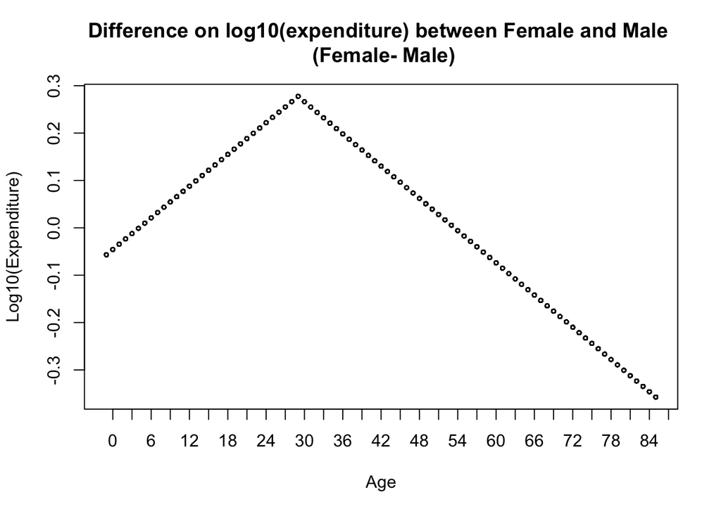

```r
fitmlr <- lm(lexp~ h129.AGE09X + agesp1 + gender + h129.AGE09X*gender + agesp1*gender
           , data = newdata)
diff <- function(gender,age){

  agesp   <- ifelse(age > 29, age-29, 0)
  logdiff <- -(0.045728771-0.011149100*age + 0.022488242*agesp)
  return(logdiff)

}

y_output <- diff(newdata$gender,newdata$h129.AGE09X)

# make a plot of the difference between women and men in the expected  log10(expenditure) as a function of age based on the fitmlr model.

plot(newdata$h129.AGE09X,y_output,cex=0.5,xaxt='n', xlab='Age',
     ylab='Log10(Expenditure)',main = 'Difference on log10(expenditure) between Female and Male \n (Female- Male)')
axis(1,seq(0,90,by=3))
```

**4.6 Influential observations for candidate model - mutivarirate linear regression model**

Here, I plot the DFBETAs for age against the predicted log10(exp) to identify highly influential observations. 772 highly influential observations were dropped. Then, use the rest of the dataset refit the model.

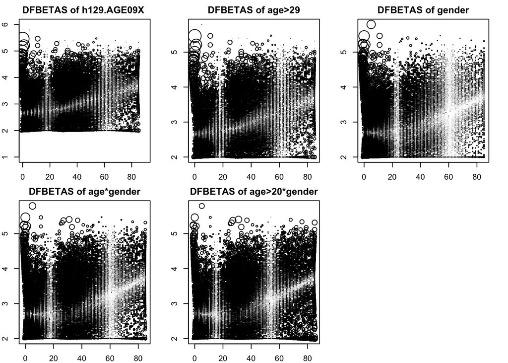

```r
library(olsrr)
fitmlr <- lm(lexp~ h129.AGE09X + agesp1 + factor(gender) +
             h129.AGE09X*factor(gender) + agesp1*factor(gender)
           , data = newdata)

infm   <- influence.measures(fitmlr)

par(mfrow=c(2,3))
par(mar=c(2, 2, 2, 2))

size <- abs(infm$infmat[,2])*50
plot(newdata$h129.AGE09X,newdata$lexp,xlim = c(1,90),ylim = c(1,6),
     cex=size, main="DFBETAS of h129.AGE09X ")

size1 <- abs(infm$infmat[,3])*50
plot(newdata$h129.AGE09X,newdata$lexp,
     cex=size, main="DFBETAS of age>29")

size2 <- abs(infm$infmat[,4])*50
plot(newdata$h129.AGE09X,newdata$lexp,
     cex=size2, main="DFBETAS of gender")

size3 <- abs(infm$infmat[,5])*50
plot(newdata$h129.AGE09X,newdata$lexp,
     cex=size3, main="DFBETAS of age*gender")

size4 <- abs(infm$infmat[,6])*50
plot(newdata$h129.AGE09X,newdata$lexp,
     cex=size4, main="DFBETAS of age>20*gender")
```

```r
#Drop the data
remove <- which( ( abs(infm$infmat[,2] )> (2/sqrt(nrow(newdata)) )  &
                   ( abs(infm$infmat[,4] )> (2/sqrt(nrow(newdata))) )))
####################New data set######################

renewdata<-newdata[-remove,]

######################################################
number_of_remove <- nrow(newdata)-nrow(renewdata)
number_of_remove <- as.data.frame(number_of_remove)
kable(number_of_remove)%>%
  kable_styling(bootstrap_options = "striped", full_width = F)
```

| number_of_remove |
| --- |
| 772 |

**4.7 Refit MLR model**

```r
re.agesp1<-ifelse(renewdata$h129.AGE09X>29,renewdata$h129.AGE09X-29,0)
refitmlr<-lm(lexp~ h129.AGE09X + re.agesp1 + factor(gender) +
              h129.AGE09X*factor(gender) + re.agesp1*factor(gender)
            , data = renewdata)
summary(refitmlr)
```

```
##
## Call:
## lm(formula = lexp ~ h129.AGE09X + re.agesp1 + factor(gender) +
##     h129.AGE09X * factor(gender) + re.agesp1 * factor(gender),
##     data = renewdata)
##
## Residuals:
##      Min       1Q   Median       3Q      Max
## -1.76900 -0.49951 -0.04599  0.43383  3.08007
##
## Coefficients:
##                               Estimate Std. Error t value Pr(>|t|)
## (Intercept)                  2.5646484  0.0141780 180.890  < 2e-16 ***
## h129.AGE09X                  0.0091228  0.0006639  13.741  < 2e-16 ***
## re.agesp1                    0.0061588  0.0009163   6.721 1.83e-11 ***
## factor(gender)1              0.2065513  0.0186550  11.072  < 2e-16 ***
## h129.AGE09X:factor(gender)1 -0.0213582  0.0009038 -23.631  < 2e-16 ***
## re.agesp1:factor(gender)1    0.0302307  0.0012938  23.366  < 2e-16 ***
## ---
## Signif. codes:  0 '***' 0.001 '**' 0.01 '*' 0.05 '.' 0.1 ' ' 1
##
## Residual standard error: 0.6525 on 36077 degrees of freedom
## Multiple R-squared:  0.1903, Adjusted R-squared:  0.1902
## F-statistic:  1696 on 5 and 36077 DF,  p-value: < 2.2e-16
```

## V. Results

**5.1 Defination of the final MLR model**

$$\begin{eqnarray}
E[log_{10}(expenditure)] = 2.5646 + 0.0091*age &+& 0.0061I(age>29)^+ + 0.2065\times gender(male)\\
&-&0.0214\times age\times gender(male) + 0.0302I(age>29)^+\times gender(male)
\end{eqnarray}$$

**5.2 Estimation of log10(expenditure) for each cluster**

log10(expenditure) of Male < 29 years old: $\beta_0+ \beta_1+ \beta_3+ \beta_4$

log10(expenditure) of Female < 29 years old: $\beta_0+ \beta_1$

log10(expenditure) of Male > 29 years old: $\beta_0+ \beta_1+\beta_2+\beta_3+ \beta_4+\beta_5$

log10(expenditure) of Female > 29 years old: $\beta_0+ \beta_1+\beta_2$

the intercept: $\beta_0$ = 2.5646

**5.3 Coefficient interpretation**

$\beta_3+\beta_4+\beta_5$ = 0.2154: hold all other variables unchange, the difference of expected log10(expenditure) for male and female who >=29 years old is 0.2154 dollars.

**5.4 Difference of log10(expenditure) between gender** Next, use the esticon function in R to calculate the estimated difference between female and male in averag of log10(exp.) and its standard error at age 40,age 65, and age 80. See the table below.

```r
library(doBy)
refitmlr <- lm(lexp ~ h129.AGE09X + re.agesp1 + factor(gender) + h129.AGE09X*factor(gender)
             + re.agesp1*factor(gender), data = renewdata)

estimate <- function(age){
  lamda <- c(0,0,0,-1,-age,-(age-29))
  e <- esticon(refitmlr,lamda)
  mytable <- data.frame(e$estimate,e$std.error,e$lwr,e$upr)

return(mytable)
}

table11<-rbind(estimate(40),estimate(65),estimate(80))

rownames(table11)<-c('40','65','80')

colnames(table11)<-c('Estimated Diff(F-M) In \n Log10(exp.)','Std Error','95% CI Lower','95% CI Upper' )

kable(table11)%>%
  kable_styling()
```

|  | Estimated Diff(F-M) In Log10(exp.) | Std Error | 95% CI Lower | 95% CI Upper |
| --- | --- | --- | --- | --- |
| 40 | 0.3152394 | 0.0094213 | 0.2967733 | 0.3337054 |
| 65 | 0.0934262 | 0.0127568 | 0.0684224 | 0.1184300 |
| 80 | -0.0396617 | 0.0196356 | -0.0781481 | -0.0011753 |

**5.5 Inference of medical expenditure and its’ standard error - boostrap and delta method approach**

```r
###############Delta Method###############
library(msm)

ages <- c(40,65,80)
d1 <- deltamethod(~10^(x1+40*x2+(40-29)*x3)-
                    10^(x1+40*x2+(40-29)*x3+x4+40*x5+(40-29)*x6),
            coef(refitmlr), vcov(refitmlr))


d2 <- deltamethod(~10^(x1+65*x2+(65-29)*x3)-
              10^(x1+65*x2+(65-29)*x3+x4+65*x5+(65-29)*x6),
            coef(refitmlr), vcov(refitmlr))

d3 <- deltamethod(~10^(x1+80*x2+(80-29)*x3)-
              10^(x1+80*x2+(80-29)*x3+x4+80*x5+(80-29)*x6),
            coef(refitmlr), vcov(refitmlr))

###############Bootstrap#############

#my nboots = 100  #1000 , 10000

Boots <- function(exps,age,gender,wantedage, nboots=100){

  diffmeanest <- matrix(NA,nrow=nboots)
  rawdat      <- data.frame(exps,age,gender)
  rawdata1    <- rawdat[!is.na(rawdat[,1]) & !is.na(rawdat[,2])& !is.na(rawdat[,3]), ]
  for (i in 1:nboots) {
    idexsamp <- sample(1:nrow(rawdata1),nrow(rawdata1),replace = T)
    datasam  <- rawdata1[idexsamp,] # get rows of the data
    age29    <- ifelse(datasam[,2]>29, datasam[,2]-29, 0)
    bootsfit <- lm(datasam[,1]~datasam[,2]+ age29+ gender+ datasam[,2]*gender+
                   age29*gender)

    diffmean <- 10^( coef(bootsfit)[1] + coef(bootsfit)[2]*wantedage + coef(bootsfit)[3]*(wantedage-29) )-
               (10^(coef(bootsfit)[1]+ coef(bootsfit)[2]*wantedage+ coef(bootsfit)[3]*(wantedage-29) +
                coef(bootsfit)[4]+ coef(bootsfit)[5]*(wantedage)+ coef(bootsfit)[6]*(wantedage-29)))

    diffmeanest[i,] <- diffmean
  }

  varout <- apply(diffmeanest,2,var)
  #median<- median(diffmeanest)
  #ci    <- quantile(diffmeanest,c(.25,.975))
  sd.err <- sqrt(varout)
  return(sd.err)
}

b1 <- Boots(renewdata$lexp,renewdata$h129.AGE09X,renewdata$gender,40)
b2 <- Boots(renewdata$lexp,renewdata$h129.AGE09X,renewdata$gender,65)
b3 <- Boots(renewdata$lexp,renewdata$h129.AGE09X,renewdata$gender,80)
```

```r
# Invert log10expenditure back to normal scale

###############Compute Median#############

fmage <- function(age){

  lamdaf <- c( 1, age, (age-29), 0, 0, 0)
  f      <- esticon(refitmlr,lamdaf)$estimate
  lamdam <- c( 1, age,(age-29),1,age,(age-29))
  m      <- esticon(refitmlr,lamdam)$estimate
  diff   <- (10^(f)-10^(m))

  return(diff)
}
```

```r
cis <- cbind(rbind(fmage(40)-b1*1.96,fmage(65)-b1*1.96,fmage(65)-b1*1.96),
      rbind(fmage(40)+b1*1.96,fmage(65)+b1*1.96,fmage(65)+b1*1.96))


median <- rbind(fmage(40),fmage(65),fmage(80))
deltamethod <- rbind(d1,d2,d3)
table12 <- data.frame(median,deltamethod,rbind(b1,b2,b3),cis)


colnames(table12) <- c('Estimated Diff In Median expend','Std Error(Delta Method)',
                     'Std Error(bootstrap)',  ' 95%CI lower ',' 95%CI upper' )
row.names(table12) <- c('40','65','80')
kable(table12) %>%
  kable_styling(bootstrap_options = "striped", full_width = F)
```

[output not shown]

[output not shown]